# Rank Filters and Mathematical Morphology

# Rank Filters and Mathematical Morphology

Replace local pixel averages with order statistics such as medians and quantiles. Compare their behavior on noisy images and connect extreme ranks with erosion, dilation, and other morphological operations.

## Run this tour

Run the cells in order with a Python 3 kernel. The first cell locates the companion data and toolbox and installs missing dependencies when needed. All worked examples include their implementation directly in this notebook. Random seeds make comparisons reproducible; you can change them to explore other samples.

```python
# Locate the companion toolbox locally, or fetch it for a standalone/Colab copy.
from pathlib import Path
import importlib.util
import os
import subprocess
import sys

working = Path.cwd()
candidates = [working, working / "python", working.parent / "python"]
python_dir = next((p for p in candidates if (p / "nt_toolbox").is_dir()), None)
if python_dir is None:
    checkout = working / "numerical-tours-support"
    if not checkout.exists():
        subprocess.run(
            [
                "git",
                "clone",
                "--depth",
                "1",
                "--branch",
                "master",
                "https://github.com/gpeyre/numerical-tours.git",
                str(checkout),
            ],
            check=True,
        )
    python_dir = checkout / "python"
os.chdir(python_dir)
if str(python_dir) not in sys.path:
    sys.path.insert(0, str(python_dir))
requirements = python_dir / "requirements.txt"
if any(
    importlib.util.find_spec(name) is None
    for name in [
        "numpy",
        "scipy",
        "matplotlib",
        "skimage",
        "sklearn",
        "pywt",
        "ipywidgets",
        "cvxpy",
        "skfmm",
        "autograd",
        "progressbar",
        "celer",
    ]
):
    subprocess.run(
        [sys.executable, "-m", "pip", "install", "-r", str(requirements)], check=True
    )

import numpy as np
import matplotlib.pyplot as plt

np.random.seed(0)
plt.rcParams.update(
    {
        "figure.figsize": (8, 4),
        "figure.dpi": 100,
        "axes.spines.top": False,
        "axes.spines.right": False,
        "font.size": 11,
        "image.cmap": "gray",
    }
)
%matplotlib inline
```

This numerical tour explores non-linear local filters that proceeds by ordering the pixels in a neighboorhood and selecting a given ranked entry.

```python
import numpy as np
import scipy as scp
import pylab as pyl
import matplotlib.pyplot as plt

from nt_toolbox.general import clamp, np, plt, pylab
from nt_toolbox.signal import imageplot, load_image, np, plt, pylab

import warnings

%matplotlib inline
```

## Continuous Rank Filtering

We consider an image $f : [0,1]^2 \rightarrow \RR$.

One usually assumes that $B$ is the ball of radius $\epsilon>0$ $$ B = B_\epsilon = \enscond{x}{\norm{x} \leq \epsilon}. $$

The operator $\phi_\beta^B$ is contrast-invariant, meaning that it computes with increasing functions $ \psi : \RR \rightarrow \RR $ $$ \phi_\beta^B \circ \psi = \psi \circ \phi_\beta^B. $$ The axiomatic study of contrast invariant operator was initiated in the comunity of mathematical morphology, see Matheron75, Tukey77, Serra82.

Note also that there exist generalization of rank filters (and in particular the median filter) to vector valued images $ f : [0,1]^2 \rightarrow \RR^d$. Since the notion of rank does not exists anymore, one has to rely on variational caracteriation of the median, see for instance CasSapChu00.

The medial filtering is the most popular rank filter. It is particularly efficient to remove impulse noise, see for instance Piterbarg84, FanHall94. See also AriasDon99 for a theoretical analysis of median filtering and of a two-stage iterated version.

## Patches in Images

We apply rank filters to discretized images by interpreting them as piecewise constant functions.

Size $N = n \times n$ of the image.

```python
n = 256
```

We load an image $f_0 \in \RR^N$.

```python
f0 = load_image("nt_toolbox/data/hibiscus.bmp", n)
```

Display $f_0$.

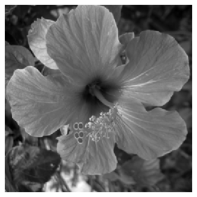

```python
plt.figure(figsize=(5, 5))
imageplot(f0)
```

Noise level $\si$.

```python
sigma = 0.04
```

Generate a noisy image $f=f_0+\epsilon$ where $\epsilon \times \Nn(0,\si^2\text{Id}_N)$.

```python
from numpy import random

f = f0 + sigma * random.standard_normal((n, n))
```

Display $f$.

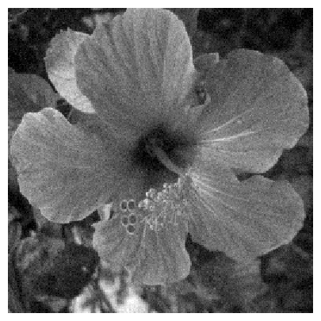

```python
plt.figure(figsize=(5, 5))
imageplot(clamp(f))
```

For simplicity, we consider the case where the set $B$ is a square of $w_1 \times w_2$ pixels. where we denote $w$ to be the half width of the patches, and $w_1=2w+1$ the full width.

```python
w = 3
w1 = 2 * w + 1
```

We define the patch extraction operator $$ p = p_x(f) \in \RR^{w_1 \times w_1} \qwhereq \forall -w \leq s_1,s_2 \leq w, \quad p(s) = f(x+s). $$

We now define the function $\Pi(f) = (p_x(f))_x $ that extracts all possible patches.

We set up large $(n,n,w_1,w_1)$ matrices to index the the X and Y position of the pixel to extract.

```python
[X, Y, dX, dY] = np.meshgrid(
    np.arange(1, n + 1), np.arange(1, n + 1), np.arange(-w, w + 1), np.arange(-w, w + 1)
)
X = X + dX
Y = Y + dY
```

We handle boundary condition by reflexion.

```python
X[X < 1] = 2 - X[X < 1]
Y[Y < 1] = 2 - Y[Y < 1]
X[X > n] = 2 * n - X[X > n]
Y[Y > n] = 2 * n - Y[Y > n]
```

Patch extractor operator $\Pi$.

```python
I = (X - 1) + (Y - 1) * n
for i in range(n // w):
    for j in range(n // w):
        I[i, j] = np.transpose(I[i, j])

Pi = lambda f: np.reshape(np.ravel(f)[I], (n, n, w1 * w1))
```

We store the patches $\Pi(f)$ as a $n \times n \times w_1^2$ matrix $P$ such that, for each pixel $x$, $P(x)$ is a vector of size $w_1^2$ storing the entries of $p_x(f)$.

```python
P = Pi(f)
```

Display some example of patches.

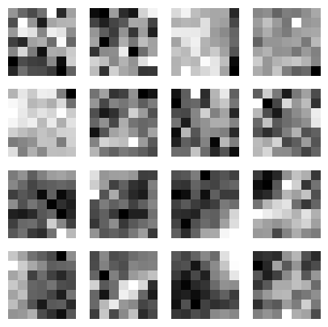

```python
from numpy import random

plt.figure(figsize=(5, 5))

for i in range(16):
    x = random.randint(n)
    y = random.randint(n)
    imageplot(np.reshape(P[x, y], (w1, w1)), "", [4, 4, i + 1])
```

## Linear Filter

A linear filter (convolution) can be computed using this patch representation as $$ g(x) = \sum_{i} \la_i p_x(f)_i. $$

In the case where $\la_i=1/w_1^2$, this defines the mean value inside the patch: $$ g(x) = \frac{1}{w_1^2} \sum_{i} p_x(f)_i. $$

```python
Pmean = lambda f: np.mean(Pi(f), 2)
```

Display it.

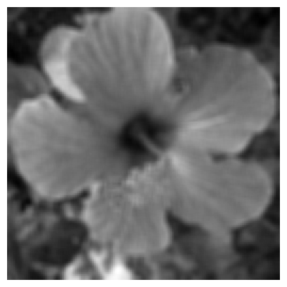

```python
plt.figure(figsize=(5, 5))
imageplot(Pmean(f))
```

Note that this is not a rank filter (this a linear filter) and that it is not contrast invariant. This is shown by displaying $$ \phi_\beta^B(f) - \psi^{-1} \circ \phi_\beta^B \circ \psi(f) $$ which is non-zero.

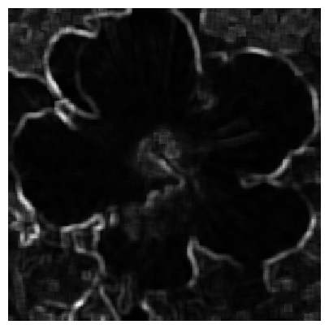

```python
p = 100
psi = lambda f: f ** (1 / p)
ipsi = lambda f: f**p

plt.figure(figsize=(5, 5))
imageplot(Pmean(abs(f)) - ipsi(Pmean(psi(abs(f)))))
```

## Opening and Closing Rank Filters

We now come back to the discrete computation of a rank filter $\phi_\be^B$ for $B$ a square of width $w_1 \times w_1$ pixels.

It is defined as $g=\phi_\beta^B(f)$ where $$ g(x) = \text{rank}_{r(\beta)}( p_x(f) ) $$ where $\text{rank}_r(v)$ extracted the element of order $k$ in the sorted value of $v \in \RR^Q$ (here $Q=w_1^2$). More precisely, we denote $$ v_{\si(1)} \leq v_{\si(2)} \leq \ldots \leq v_{\si(Q)} $$ where $\si \in \Sigma_Q$ is an ordering permutation, which can be computed in $ O(N \log(N)) $ operations with the QuickSort algorithm. Then the ranked valued is $$ \text{rank}_r(v) = v_{\si(r)}. $$

In order to be consistent with the continuous definition of the rank filter, one should define the rank as $$ r=r(\beta) = \lfloor Q r \rfloor. $$

```python
r = lambda beta: int(min(np.ceil(beta * w1 * w1), w1 * w1 - 1))
```

Shortcut for the rank filter.

```python
subsample = lambda x, s: x[:, :, s]
phi = lambda f, beta: subsample(np.sort(Pi(f), 2), r(beta))
```

**Worked example 1**

Compute the rank filter for several values of $\beta$.

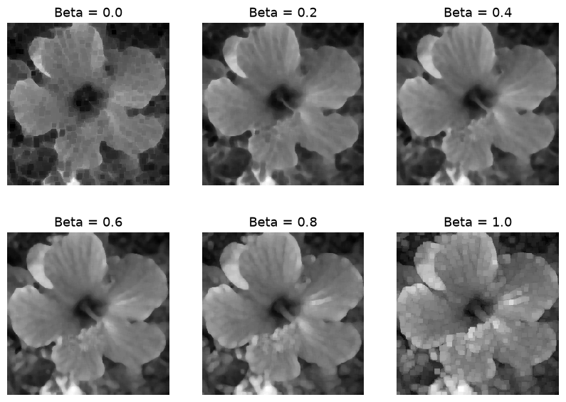

```python
plt.figure(figsize=(10, 7))

beta_list = np.linspace(0, 1, 6)

for i in range(len(beta_list)):
    beta_c = beta_list[i]
    imageplot(phi(f, beta_c), "Beta = %.1f" % beta_c, [2, 3, i + 1])
```

The case $\beta=0$ corresponds to the closing operator from mathematical morphology (min filter).

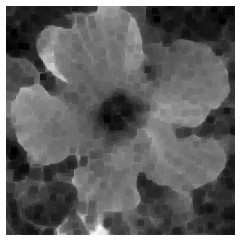

```python
closing = lambda f: phi(f, 0)
plt.figure(figsize=(5, 5))
imageplot(closing(f))
```

The case $\beta=1$ corresponds to the opening operator from mathematical morphology (max filter).

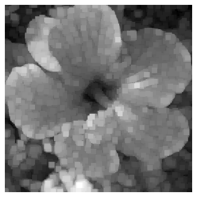

```python
opening = lambda f: phi(f, 1)
plt.figure(figsize=(5, 5))
imageplot(opening(f))
```

**Worked example 2**

Compute a closing followed by an opening.

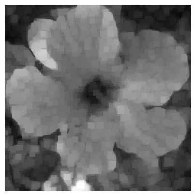

```python
plt.figure(figsize=(5, 5))
closingopening = lambda f: opening(closing(f))
imageplot(closingopening(f))
```

**Worked example 3**

Compute an opening followed by a closing.

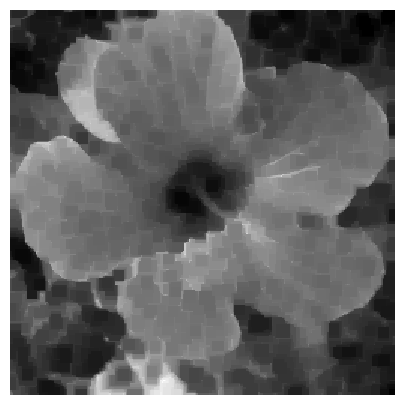

```python
plt.figure(figsize=(5, 5))
openingclosing = lambda f: closing(opening(f))
imageplot(openingclosing(f))
```

**Worked example 4**

Perform iterated opening and closing.

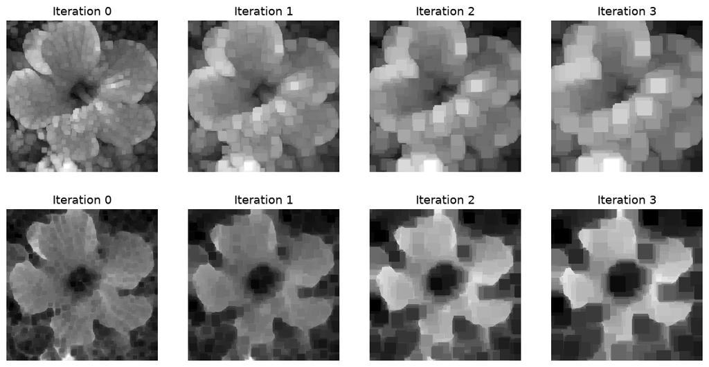

```python
plt.figure(figsize=(14, 7))

f1 = f
for i in range(4):
    f1 = opening(f1)
    imageplot(f1, "Iteration %i" % i, [2, 4, i + 1])

f1 = f
for i in range(4):
    f1 = closing(f1)
    imageplot(f1, "Iteration %i" % i, [2, 4, i + 5])
```

## Median Filter

The median filter corresponds to the case where $\be=1/2$.

```python
medfilt = lambda f: phi(f, 1 / 2)
```

Display the result.

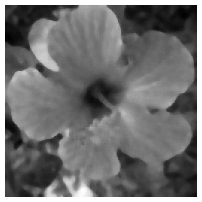

```python
plt.figure(figsize=(5, 5))
imageplot(medfilt(f))
```

Iterated median filtering computes $$ f^{(\ell+1)} = \phi_{1/2}^B( f^{(\ell)} ). $$

In the case where $f$ is of class $C^3$ and $\nabla f(x) \neq 0$, one has the following Taylor expansion $$ \phi_{1/2}^{B_\epsilon}(x) = f(x) + \frac{\epsilon^2}{6} \norm{\nabla f(x)} \text{Curv}(f)(x) + O(\epsilon^{7/3}) $$ where the curvature operator is $$ \text{Curv}(f) = \text{div}\pa{ \frac{\nabla f}{\norm{\nabla f}} }. $$

Intuitively, it means that if one iterates the operator $ \phi_{1/2}^{B_\epsilon} $ with a proper re-scaling $\ell \leftrightarrow t$ and when $\epsilon \rightarrow 0$, then $f^{(\ell)}$ tends to the solution to the famous mean-curvature motion PDE $$ \pd{f}{t} = \norm{\nabla f} \text{Curv}(f). $$

This conjecture was initially mentionned in BeMerOsh92. This was rigorously proved in Ishii95, BarGeorg, Evans93 using the machinery of viscosity solutions.

Similar result holds for other class of contrast invariant operator, see for instance Cao98 for affine invariant operators, and GuiMoRy04 for an axiomatic and general framework.

**Worked example 5**

Perform iterated median filtering, and store the output in $f_1$.

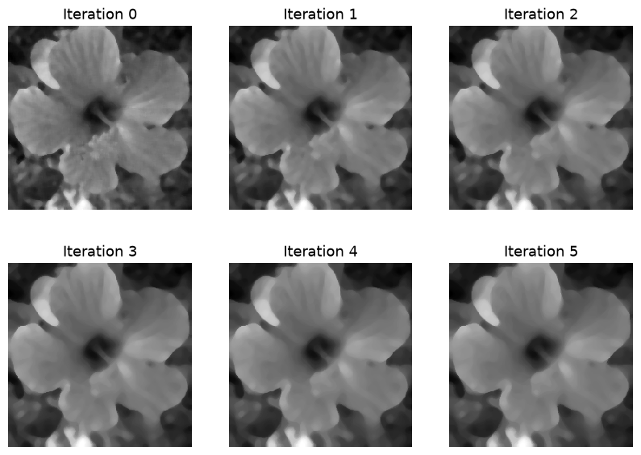

```python
plt.figure(figsize=(10, 7))

f1 = f
for i in range(6):
    f1 = medfilt(f1)
    imageplot(f1, "Iteration %i" % i, [2, 3, i + 1])
```

Display.

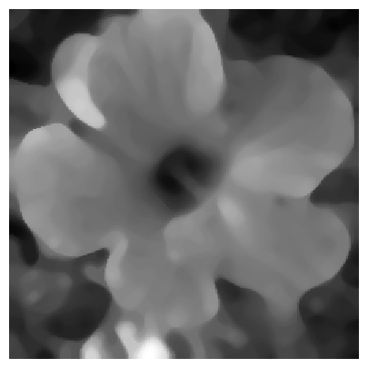

```python
plt.figure(figsize=(5, 5))
imageplot(f1)
```

## References and further reading

- [Matheron75] G. Matheron, [Random Sets and Integral Geometry][1], Wiley, New York, 1975
- [Serra82] J. Serra, [Image Analysis and Mathematical Morphology][2], Academic Press, London, 1982
- [Tukey77] J. W. Tukey, [Exploratory Data Analysis][3]. Addison-Wesley, Reading, MA, 1977
- [BeMerOsh92] J. Bence, B. Merriman, S. Osher, [Diffusionn generated motion by mean curvature][4], Selected Lectures in Math. Amer. Math. Soc., Providence, 1992
- [Cao98] F. Cao, [Partial differential equations and mathematical morphology][5]. J.Math. Pures Appl. 77 909?941, 1998
- [Ishii95] H. Ishii, *A generalization of the Bence, Merriman and Osher algorithm for motion by mean curvature*, 1995
- [BarGeorg] G. Barles and C. Georgelin, [A Simple Proof of Convergence for an Approximation Scheme for Computing Motions by Mean Curvature][6], SIAM J. Numer. Anal., 32(2), 484?500, 1995.
- [Evans93] L. C. Evans, [Convergence of an algorithm for mean curvature motion][7], Indiana Univ. Math. J., 42, pp. 533?557, 1993.
- Antoni Buades, Bartomeu Coll, and Jean-Michel Morel. [A Review of Image Denoising Algorithms, with a New One](https://doi.org/10.1137/040616024). 2005, Multiscale Modeling & Simulation 4(2), 490–530. Comparison of local, transform, and nonlocal denoising models.
- David L. Donoho. [De-noising by Soft-Thresholding](https://doi.org/10.1109/18.382009). 1995, IEEE Transactions on Information Theory 41(3), 613–627. Why shrinkage of wavelet coefficients suppresses noise.